# GANs - final report

Szymon Czop Marta Kałużna

30 06 2020

# GANs

## 1 Simple GAN

First GAN was introduced in paper of [Ian J.Goodfellow et al., 2014](https://arxiv.org/pdf/1406.2661.pdf). The basic concept of this paper is to use two neural networks to generate images. The generative model G should learn the data distribution and convert it from simple distribution **z** to one that imitates the coplicated distribution represented by group of real pictures in **x** space. One the other hand we have discriminative model D that estimates the probability that sample came form the training data rather then from G. Network structure diagram below

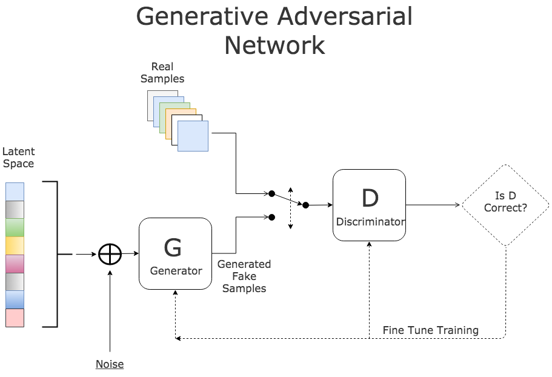

Network structure diagram

To make it happen we need to folow two-player minimax game with value function V(G,D)

$$min_Gmax_D = \mathbb{E}_{x \sim p_{data}(x)}[logD(x)] + \mathbb{E}_{z \sim p_{z}(z)}[log(1-D(G(z))]$$

One of the hardest part of training GANs is to make sure that G is not overpowering D in it’s efficiency and vice versa. It’s very important for learning reasons. If one of the nets will be much mor powerfull than the second one, learning process will be unsettled.

To prevent that, during the training process of G, instead of trying to minimize $log(1-D(G(z))))$ we will maximize $log(D(G(z)))$ as authors of paper are telling us.

For Discriminator we will use linear layers with number of neurons as follow: (input_size, 1024 ,512,256,128), after each linear layer we have dropout at level 0.3 and ReLU as activation function. Last layer is without dropout and Sigmoid is activation function. In Generator we also use linear layers in following order (size_of_latent_space,256,512,1024,784). After each linear layer we use ReLu as activation. For last layer we use Tanh for activation.

We trained our model on 200 epochs and get following results:

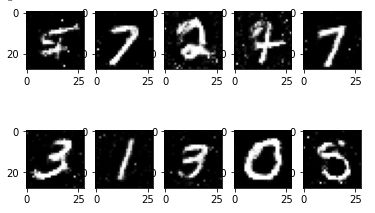

**Training process:**

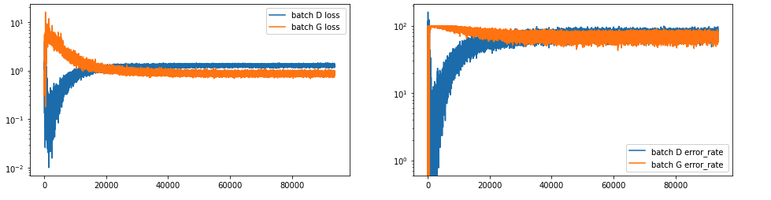

We see that over time Generator loss and error is decreasing, despite the initial adventage of Discriminator. Trianing process went well, reason why generated pictures are not perfect has to do with number of epochs. If we increase them, we would probably get better results.

# 2. BiGAN

We used the structure and idea from [Jeff Donahue et.al. 2017](https://arxiv.org/pdf/1605.09782.pdf). Now beyond of learning how to generate picture form latent space **z** to data distribution **z**, we also want to learn inverse mapping by adding encoder to its architecture

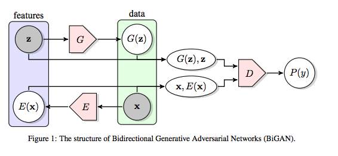

The function to minimize this time is :
$$min_{E,G}max_DV(D,E,G)$$

where $V(D,E,G) = \mathbb{E}_{x\sim{p_x}}[logD(x,E(x))] + \mathbb{E}_{z\sim{p_z}}[log(1-D(G(z),z))]$

Insted of using this complicated optimisation function we will split it to two parts that together meet it’s propery:

$$Loss_D = -\sum_{i = 1}^{m}logD(x,E(x)) + log(1-D(G(z)z))$$
$$Loss_{E,G} = -\sum_{i = 1}^{m}logD(G(z),z) + log(1-D(x,E(x)))$$

where m is size of batch.

We used same networks for G and D as in previous model. For Encoder we applied linear layers (in_features, 1024,1024,100), with LeakyReLU after first layer, LeakyReLu and BatchNorm after second and no additional features after third.

After 500 epochs we got:

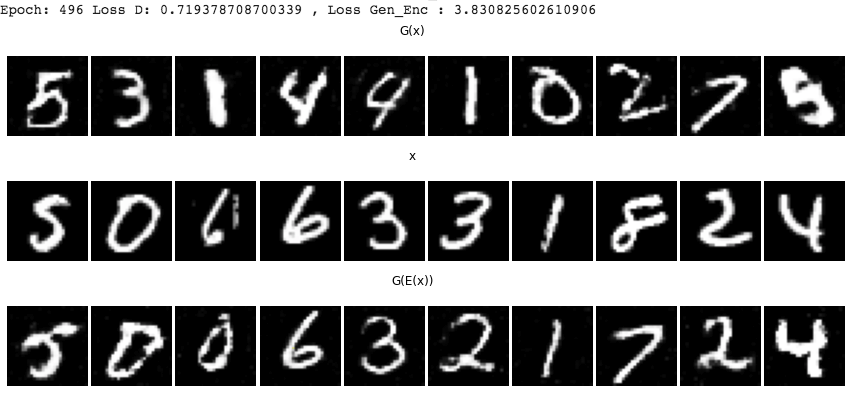

With following training process:

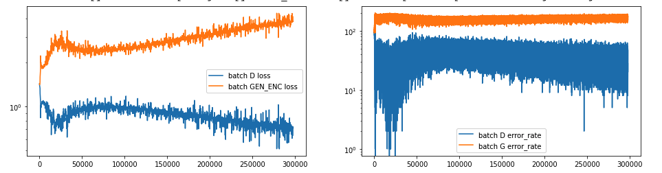

# CBiGAN

We used [Jaiswal et.al 2018](https://arxiv.org/pdf/1411.1784.pdf) for getting the idea of BiGANs. So far we know how to create images from latent space and how to turn one into it. GANs are part of unsupervised learning, thus so far we did’t have any influence what image (in our case number will be generated). To change it we need to add some part of suppervised learning. We will use one hot encoding process to tell Discriminator and Generator which number they should generate/expect. In network structure it will looks like this:

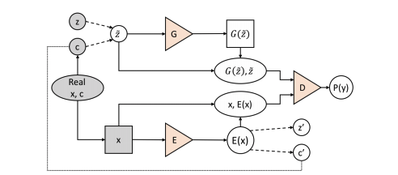

Althoug this diagram looks very complicated the main difference is that we add this one (one vector for one picture) hot encoded vector to G and D through the whole training process. We used the same networks architecture and loss function as in normal BiGAN.

Finel result on 500 epochs:

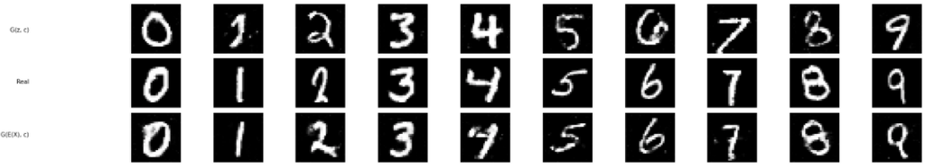

With following training process:

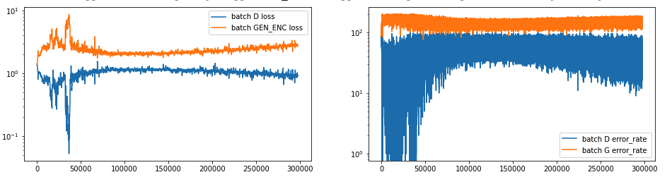

As we see for both BiGAN and CBiGAN trianing process is not so smooth and Discriminator has almost always smaller loss than Generator. Despite this, trianing process turned out to be sucessfull.

# Summary

We focus only on small part of GANs family. There is a lot more to explore in terms of structure, potential usage and dataset choice. GANs are powerfull tools that uses many networks and because of that we have same pros and cons taken to the power of networks number :). Training is very unstabile and in the middle of it we may be back to the loss values that we had at the beggining. It is very important to initialize weight and be very smooth with hyperparameter tuning. It’s a lot of fun but sometimes when you are stuck, it’s very hard to find mistake.